# MAS2908 - Practical 01 (Solutions)

Data Manipulation and Plotting in R

Clement Lee

Semester 2, 2025/2026

The purpose of this practical is to allow you to:

1. (re-)familiarise yourself with using RStudio to carry out basic operations;
2. work with and understand data frames;
3. visualise data frames with base R graphics.

# 1 Getting started with RStudio

Before we begin working with data, let’s make sure you are set up correctly in RStudio. Follow these steps at the start of each practical session:

## 1.1 Step 1: Open RStudio

On university computers, find RStudio in the Start menu or Applications folder. If you’re using your own computer, launch the RStudio application you installed.

When RStudio opens, you’ll see several panels:

- **Console** (bottom-left): Where R code is executed and output appears
- **Source** (top-left): Where you write and edit scripts (may be hidden initially)
- **Environment** (top-right): Shows variables and data you’ve created
- **Files/Plots/Help** (bottom-right): File browser, plots, and documentation

## 1.2 Step 2: Set your working directory

The **working directory** is the folder R uses by default when reading or writing files. Set it to the folder where your script and data are located.

**Option A: Using the menu**

1. Go to **Session > Set Working Directory > Choose Directory…**
2. Navigate to your folder and click “Open”

**Option B: Using code**

Add this line at the top of your script, replacing the path with your folder:

```r
setwd("H:/MAS2908/practicals")  # Windows example
setwd("~/Documents/MAS2908/practicals")  # Mac/Linux example
```

While some might recommend option B, I **strongly recommend against** it because it makes the script not reproducible, as the paths you see above might not exist on other computers.

To check your current working directory:

```r
getwd()
```

## 1.3 Step 3: Create a new R script

Go to **File > New File > R Script** (or press `Ctrl+Shift+N` on Windows, `Cmd+Shift+N` on Mac). This opens a blank script in the Source panel where you can write and save your code.

Save your script immediately: **File > Save** (or `Ctrl+S` / `Cmd+S`). Choose a sensible name like `practical01.R` and save it in your working folder.

## 1.4 Step 4: Running code

There are several ways to run code from your script:

- **Run current line**: Place cursor on a line and press `Ctrl+Enter` (`Cmd+Enter` on Mac)
- **Run selected code**: Highlight code and press `Ctrl+Enter`
- **Run entire script**: Press `Ctrl+Shift+Enter` or click “Source”

## 1.5 Step 5: Install and load packages

R packages extend the functionality of base R. In this module, we will primarily use two packages:

- **`dplyr`**: For data manipulation (filtering, sorting, summarising)
- **`ggplot2`**: For creating visualisations

**If you are using your own computer**, you need to install these packages once:

```r
install.packages("dplyr")
install.packages("ggplot2")
```

**Note**: Only run `install.packages()` in the console, not in your R script. Installation only needs to happen once, and including it in a script can cause unnecessary re-installation every time the script runs.

On university computers, these packages are already installed.

**At the start of each session**, load the packages you need:

```r
library(dplyr)
library(ggplot2)
```

# 2 Data frame basics

A data set that has been loaded into R, and is ready for analysis, is normally stored in something called a *data frame*. A data frame can be thought of as a table of data where the columns are named vectors, with each vector containing a particular *type* of data (numeric, string, date, time). These columns are often called *variables* in statistics, with the rows of the data frame corresponding to individuals or single observations.

We will use the `mpg` dataset from the `ggplot2` package to illustrate basic operations. This dataset contains fuel economy data for 234 vehicles:

```r
library(ggplot2)  # mpg is part of ggplot2
```

## 2.1 Inspecting a data frame

First, let’s check that `mpg` really is a data frame:

```r
class(mpg)
```

In R, the class of objects is very important. The same function, for example `summary()`, will perform differently depending upon the class of the object. In computer programming this is called “function overloading”.

We can use several functions to inspect the data frame:

```r
head(mpg)       # First 6 rows
dim(mpg)        # Number of rows and columns
names(mpg)      # Column names
str(mpg)        # Structure summary
```

Another way to see the contents in a spreadsheet-type view is:

```r
View(mpg)
```

**Note**: Don’t include `View()` commands in an R script. Only execute `View()` and other “interactive” commands in the console.

## 2.2 Accessing columns

To access individual variables (columns), we use the **dollar syntax**:

```r
mpg$manufacturer    # Returns the 'manufacturer' column as a vector
mpg$cty[1:5]        # Returns the first 5 elements of 'cty'
```

We can also use square brackets to select individual elements:

```r
mpg[1, 1]      # First row, first column
mpg[1, ]       # Entire first row
mpg[, 1]       # Entire first column
mpg[1:3, ]     # First 3 rows
```

**Note**: Absolute referencing like this is generally a bad idea. If the order of your columns changes, you may be referring to different columns than you thought. By using the dollar syntax, we use the name of the column rather than its location in the data frame, which makes the code easier to understand.

## 2.3 Creating new variables

Using the dollar syntax, we can create new variables:

```r
mpg$efficiency_ratio <- mpg$hwy / mpg$cty
head(mpg$efficiency_ratio)
```

This adds a new column called `efficiency_ratio` to the data frame. However, there are more elegant ways of creating new variables, as you will see in the next section.

# 3 Data manipulation with `dplyr`

The `dplyr` package provides powerful tools for manipulating data frames. Make sure you have loaded it:

```r
library(dplyr)
```

The package gives us access to four key functions:

- `filter()` - Focus on a subset of the rows of a data frame
- `arrange()` - Reorder the rows in the data frame
- `select()` - Select specific columns
- `mutate()` - Add new columns that are functions of existing ones

The first argument to each of these functions is always the data frame we wish to work on. The subsequent arguments specify the variables we want to work with.

## 3.1 filter()

To focus on specific rows based on a condition, use `filter()`. For example, to select only compact cars:

```r
compact_cars <- filter(mpg, class == "compact")
head(compact_cars)
```

We can combine multiple conditions:

```r
efficient_compact <- filter(mpg, class == "compact", cty > 20)
head(efficient_compact)
```

## 3.2 arrange()

To sort rows by a variable, use `arrange()`:

```r
# Sort by city MPG (ascending by default)
arrange(mpg, cty) |> head()

# Sort by city MPG (descending)
arrange(mpg, desc(cty)) |> head()
```

## 3.3 select()

To choose specific columns, use `select()`:

```r
# Select only manufacturer, model, and city MPG
mpg_subset <- select(mpg, manufacturer, model, cty)
head(mpg_subset)
```

## 3.4 mutate()

To create new variables based on existing ones, use `mutate()`:

```r
mpg_new <- mutate(mpg,
    avg_mpg = (cty + hwy) / 2,
    efficiency = hwy / displ
)
head(select(mpg_new, model, cty, hwy, avg_mpg, efficiency))
```

When using `mutate()`, you refer to columns by name directly without the dollar syntax. This makes the code cleaner and easier to read.

## 3.5 The pipe operator

When performing multiple operations on data, we often need to chain several functions together. R provides the **pipe operator** `|>` (introduced in R 4.1) to make this easier to read.

The pipe takes the result of the expression on its left and passes it as the first argument to the function on its right:

```r
# Without pipe: nested functions (read inside-out)
head(arrange(filter(mpg, class == "suv"), desc(cty)))

# With pipe: left to right (read naturally)
mpg |>
  filter(class == "suv") |>
  arrange(desc(cty)) |>
  head()
```

Both produce the same result, but the piped version is easier to read: “Take mpg, then filter for SUVs, then arrange by city MPG, then show the head.”

You can combine all four `dplyr` functions with the pipe:

```r
mpg |>
  filter(year == 2008) |>
  mutate(efficiency = hwy / displ) |>
  arrange(desc(efficiency)) |>
  select(manufacturer, model, efficiency) |>
  head()
```

**Note**: You may also see `%>%` in older code or online examples. This is the pipe operator from the `magrittr` package (loaded with `dplyr`). The native pipe `|>` works the same way for most purposes and doesn’t require loading any packages.

## 3.6 Exercises: Data manipulation

1. Using the `mpg` dataset:
   1. Filter to show only cars from the year 1999.
   2. Arrange the result by highway MPG in descending order.
   3. Select only the manufacturer, model, and hwy columns.

   ```r
   mpg |>
     filter(year == 1999) |>
     arrange(desc(hwy)) |>
     select(manufacturer, model, hwy)
   ```

   ```
   ## # A tibble: 117 × 3
   ##    manufacturer model        hwy
   ##    <chr>        <chr>      <int>
   ##  1 volkswagen   jetta         44
   ##  2 volkswagen   new beetle    44
   ##  3 volkswagen   new beetle    41
   ##  4 toyota       corolla       35
   ##  5 honda        civic         33
   ##  6 toyota       corolla       33
   ##  7 honda        civic         32
   ##  8 honda        civic         32
   ##  9 honda        civic         32
   ## 10 toyota       corolla       30
   ## # ℹ 107 more rows
   ```

2. Create a new variable called `mpg_diff` that is the difference between highway and city MPG. Which car has the largest difference?

   ```r
   mpg |>
     mutate(mpg_diff = hwy - cty) |>
     arrange(desc(mpg_diff)) |>
     select(manufacturer, model, cty, hwy, mpg_diff) |>
     head()
   ```

   ```
   ## # A tibble: 6 × 5
   ##   manufacturer model        cty   hwy mpg_diff
   ##   <chr>        <chr>      <int> <int>    <int>
   ## 1 honda        civic         24    36       12
   ## 2 volkswagen   new beetle    29    41       12
   ## 3 audi         a4            18    29       11
   ## 4 audi         a4            20    31       11
   ## 5 chevrolet    malibu        18    29       11
   ## 6 honda        civic         25    36       11
   ```

3. Rewrite the following code using the pipe operator `|>`:

   ```r
   head(select(arrange(filter(mpg, cty > 20), desc(hwy)), manufacturer, model, hwy))
   ```

   ```r
   mpg |>
     filter(cty > 20) |>
     arrange(desc(hwy)) |>
     select(manufacturer, model, hwy) |>
     head()
   ```

   ```
   ## # A tibble: 6 × 3
   ##   manufacturer model        hwy
   ##   <chr>        <chr>      <int>
   ## 1 volkswagen   jetta         44
   ## 2 volkswagen   new beetle    44
   ## 3 volkswagen   new beetle    41
   ## 4 toyota       corolla       37
   ## 5 honda        civic         36
   ## 6 honda        civic         36
   ```

# 4 Exporting & importing data

While we have been working with datasets that already exist in R packages (like `mpg` from `ggplot2`), in practice you will often need to work with data downloaded from the Internet, or save your data to share with collaborators.

## 4.1 Exporting data

Data frames only exist in your R session. When you quit R, they disappear unless you save them. A common way to export a data frame is to write it as a CSV (Comma Separated Values) file:

```r
write.csv(mpg, file = "mpg_data.csv", row.names = FALSE)
```

The `row.names = FALSE` argument prevents R from adding an extra column of row numbers.

Other formats are also available:

General formats and functions for importing and exporting data.

| Name | Extension | Write function | Read function |
| --- | --- | --- | --- |
| CSV | `.csv` | `write.csv()` | `read.csv()` |
| Tab-delimited | `.tab` | `write.table()` | `read.table()` |

## 4.2 Importing data

To import data, use the corresponding `read.*()` functions:

```r
dat <- read.csv(file = "mpg_data.csv")
```

Before importing a dataset, it’s good practice to inspect the file using a text editor to confirm its structure. The `read.table()` function is very flexible and can handle many different formats by adjusting its arguments.

## 4.3 Exercises: Exporting & importing data

1. Make sure you are familiar with writing and reading CSV files:
   1. Look up the help page for `write.csv()`.
   2. Export the first 10 rows of `mpg` to a CSV file.
   3. Read it back into R and verify the contents.

   ```r
   write.csv(head(mpg, 10), file = "mpg_sample.csv", row.names = FALSE)
   mpg_sample <- read.csv("mpg_sample.csv")
   head(mpg_sample)
   ```

# 5 Visualisation with base R graphics

This section introduces data visualisation using base R functions. We will continue using the `mpg` dataset. We focus on the `cty` variable (city miles per gallon) for single-variable plots, and the `class` variable (vehicle type) for group comparisons.

## 5.1 Exercises: Base R visualisation

1. **Histogram**: Create a histogram of `cty` using `hist()`.
   1. Use the argument `col = "lightblue"` to fill the bars.
   2. Add appropriate axis labels using `xlab` and `ylab`.
   3. Experiment with different numbers of bins using the `breaks` argument.

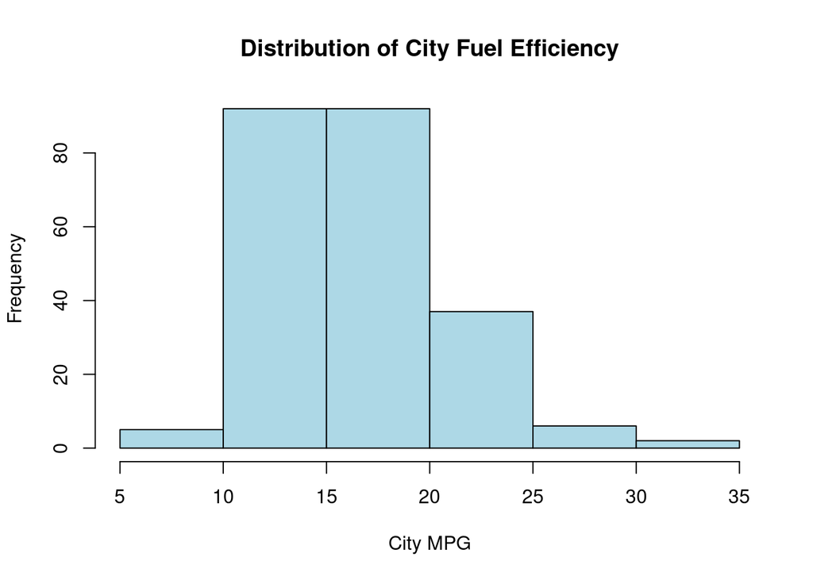

   ```r
   hist(mpg$cty, col = "lightblue",
        xlab = "City MPG", ylab = "Frequency",
        main = "Distribution of City Fuel Efficiency")
   ```

2. **Density plot**: Create a density plot of `cty`.
   1. First compute the density using `density(mpg$cty)`.
   2. Then plot it using `plot()`.
   3. Add a rug plot underneath using `rug()`.

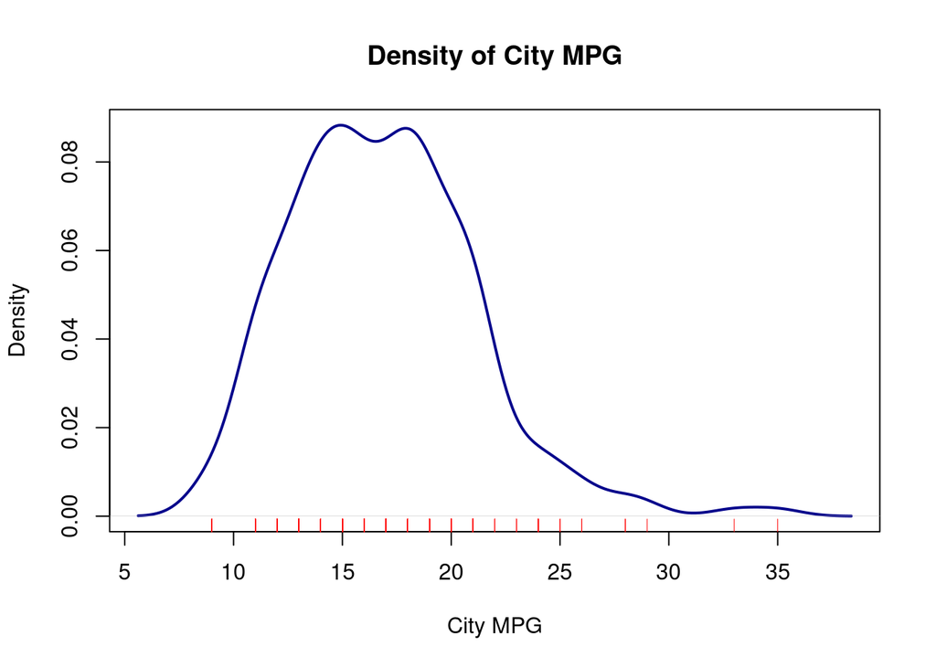

   ```r
   plot(density(mpg$cty), main = "Density of City MPG",
        xlab = "City MPG", col = "darkblue", lwd = 2)
   rug(mpg$cty, col = "red")
   ```

3. **Bar chart**: Create a bar chart of `class` (vehicle type).
   1. Use `barplot(table(mpg$class))`.
   2. Add appropriate axis labels.
   3. Which vehicle class is most common in the dataset?

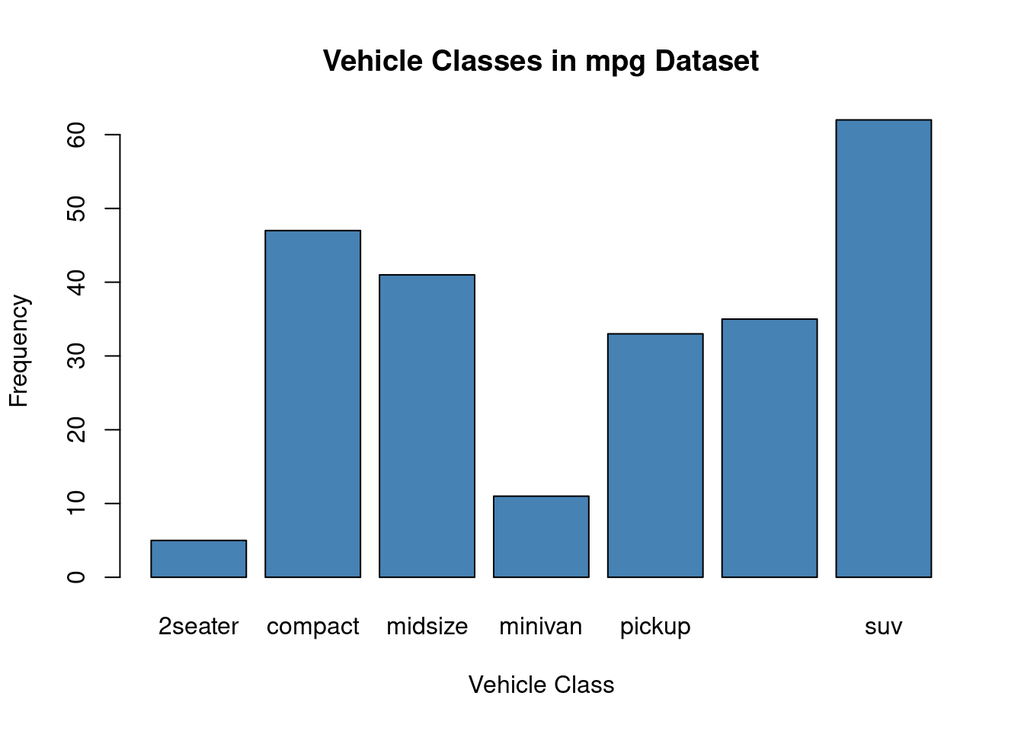

   ```r
   barplot(table(mpg$class), xlab = "Vehicle Class", ylab = "Frequency",
           col = "steelblue", main = "Vehicle Classes in mpg Dataset")
   ```

   ```r
   # SUV is the most common vehicle class
   ```

4. **Scatterplot**: Explore the relationship between two continuous variables.
   1. Create a scatterplot of `cty` ($y$-axis) vs `hwy` ($x$-axis) using `plot()`.
   2. Add a regression line using `abline(lm(cty ~ hwy, data = mpg))`.
   3. Describe the relationship you observe.

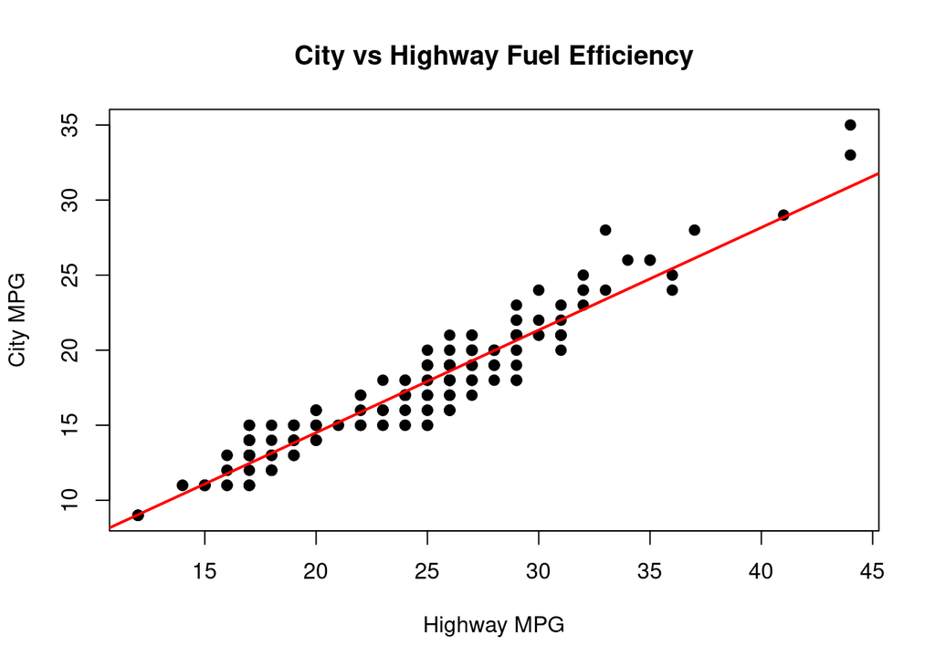

   ```r
   plot(mpg$hwy, mpg$cty, xlab = "Highway MPG", ylab = "City MPG",
        main = "City vs Highway Fuel Efficiency", pch = 19)
   abline(lm(cty ~ hwy, data = mpg), col = "red", lwd = 2)
   ```

   ```r
   # Strong positive linear relationship: higher highway MPG = higher city MPG
   ```

5. **Line plot**: Create a line plot using the `economics` dataset.
   1. Plot `psavert` (personal savings rate) over time using `plot(economics$date, economics$psavert, type = "l")`.
   2. Add appropriate axis labels.
   3. Describe the trend you observe.

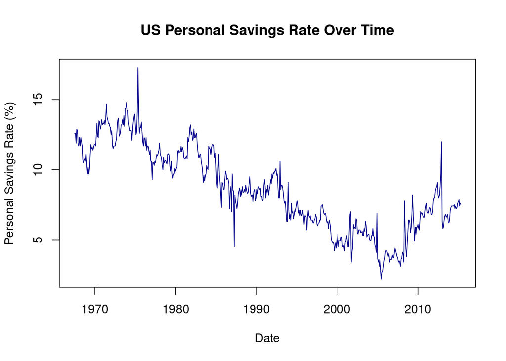

   ```r
   plot(economics$date, economics$psavert, type = "l",
        xlab = "Date", ylab = "Personal Savings Rate (%)",
        main = "US Personal Savings Rate Over Time", col = "darkblue")
   ```

   ```r
   # General declining trend from 1970s to 2005, then increase after 2008 crisis
   ```

6. **Stripchart**: Create a stripchart of `cty` by `class`.
   1. Use `stripchart(cty ~ class, data = mpg, method = "jitter")`.
   2. Set `vertical = TRUE` to show values on the $y$-axis.
   3. Add appropriate axis labels.

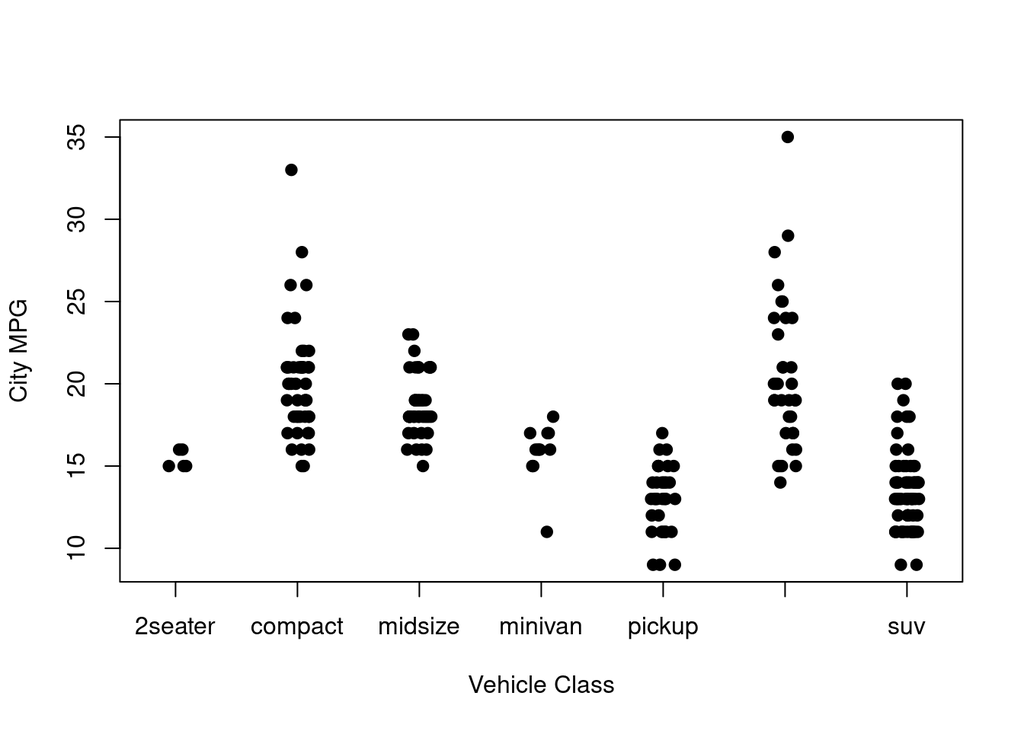

   ```r
   stripchart(cty ~ class, data = mpg, method = "jitter",
              vertical = TRUE, pch = 19,
              xlab = "Vehicle Class", ylab = "City MPG")
   ```

7. **Boxplot**: Compare the distribution of `cty` across vehicle classes.
   1. Create a boxplot using `boxplot(cty ~ class, data = mpg)`.
   2. Add appropriate axis labels.
   3. Which vehicle class has the best city fuel efficiency? Which has the most variability?

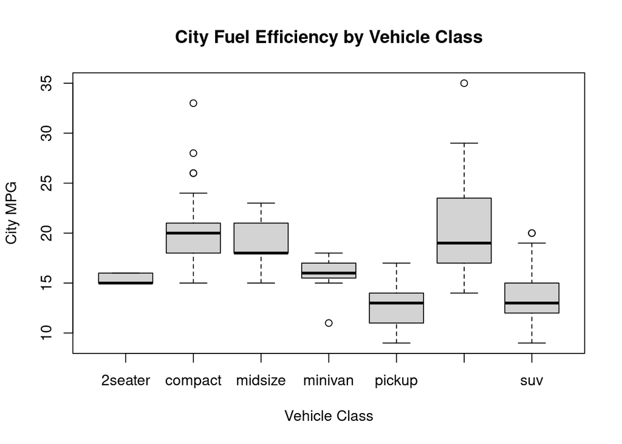

   ```r
   boxplot(cty ~ class, data = mpg,
           xlab = "Vehicle Class", ylab = "City MPG",
           main = "City Fuel Efficiency by Vehicle Class")
   ```